# Class Notes

Jessica Hunter

3/16/2022

## Basics

### rStudio basics

from week_1 lectures

**script window** type what you want to do and run when ready, saves scripts  
**“<-”** means to assign to object  
**“#”** means to ignore, great pace for comments  
spelling punctualization, capitalization all matter  
functions are “canned scripts of convenient or complex commands  
**"?"** in front of function is help and will ask r to tell you what it is  
**help.search("function searching for")** if looking for a function to do a particular task e.g. helpsearch(”ANOVA")  
**apropos(“nova”)** when you can only remember part of the word  
**console** whar r going to do, doesn’t save **“>”** means ready **“+”"** means waiting for more data, maybe didn’t give enough info  
[to install github](https://happygitwithr.com/install-git.html)  
[password authentication help](https://happygitwithr.com/https-pat.html)

### Git hub basics

from week_2

write in terminal  
**git pull** - downloads repository  
**git add testscript.r** - i want to add new files to repo, stages  
**git add week_3/** will add the whole folder  
**git commit -a -m “I am adding testscrip.R”** - saves changes  
**-a** means commits to every change; all  
**-m** means I am adding a message  
**git push** - downloads to internet  
commit often because reverting will go back to last commit  
to revert to last commit go to blue wheel

### mardown for github readme

from week_2b  
*sample* for italics  
**sample** for bold  
*sample* italics and bold  
**headers** with 1 to 5 “#”, 1 being the biggest  
**link** is “linkname”  
**reference link** “[linkname][reference link]  
reference link”  
**blockquotes** use “>” symbol in front  
**lists** use an “*" or "*” for sublist or numbers or combo  
hardbreak or paragraph with 2 spaces after each line  
[link to other markdown tutorials](https://www.markdowntutorial.com/conclusion/)

### 5 Parts of a Script

from week_2b  
1. Intro - **purpose**, name, date  
2. Libraries - name libraries using  
3. Load Data - read in data  
4. Functions - purpose of functions, functions I created  
5. Analysis - analyze results, can be in different sections  
comment comment comment - to give descriptions of each line

### Terminal commands

Create folders in terminal  
$ cd week_4 ### to go to that directory cd means current directory  
to creATE A folder  
$ mkdir foldername - to make new folder  
cd ../ - to go back up one folder  
install.packages(“packagename”) - to install packages

### how to look at data

head(data) - look at top 6  
tail(dtata) - looks at bottom 6 lines  
view(data)  
glimpse() read in data #### read_csv and read reads the file - use underscore instead of . because brings in all characters as characters WeightData<-read_csv(here(“week_2”, “data”, “weightdata.csv”))

write_csv() to create files

### Data Visualization

from week_3a&b

Responsible  
1. Correct context  
2. Clear  
3. Responsible  
4. Awesome  
5. units/labels 6. emphasize important points  
7. legends reduces eye jumping and go in logical order  
8. **labels usually easier than legends**  
9. put actual data  
10. marginal plots - summarry plus raw

Bad plots  
1. too many legends, points or variables  
2. 3D  
3. shadows  
4. fonts weird  
5. overwhelming  
6. misleading with scales (reverse scale, increase scale size)

ggplot default changes  
1. update axis  
2. reduce width of each group 3. change colors 4. x and y limits and expansion  
5. remove unnecessary gridlines  
6. remove abbreviations

### how to ask for help

type in the function and library package name both in search with question don’t use ggplot and tidyverse, bc gplot is in tidyverse 1. make sure spelled right  
2, make sure use ls() which lists everything and if not there then not created  
3. warning ignoring parameter"___" because you spelled it wrong  
4. if error in summary them might be a na or character  
5. parenthesis all there, did you store or call, 6. go to [stackoverflow](https://stackoverflow.com/) and copy and paste code  
7. [rstudio community](https://community.rstudio.com/)  
“#rstats” on twitter - no seriously, create an account. Some to follow right away for maximum R learning, commentary and community: @dataandme, @hadleywickham, @drob, @RLadiesGlobal, @WeAreRLadies, @R4DScommunity, @allison_horst, @R_LGBTQ, @JennyBryan, @juliasilge, @noamross, @kara_woo, @thomas_mock, @juliesquid, @cedsherer @ellis_hughes @geokaramanis 8. how to session for stackoverflow post - go to add in then render reprex and then current file or clipboard and github/stack overfow, and check append session and it goes to clipboard to paste into stackoverflow for help

## Libraries

**ggplot()** data visualization  
**library(palmerpenguins)** data on penguins for practice  
**library(tidyverse)**  
**dplyr** (part of tidyverse) - manipulating data - filter, select, group, summary, mutate, remove NA  
**library(here)** looks for naming scheme great for other transferring to other ppl computers with same folder naming scheme  
**library(lubridate)** for times and dates manipulation  
**library(kableExtra)** for displaying kable tables  
library(maps) library(mapproj) library(mapdata)  
**library(ggsn)** didn’t work - adds compass and scale bars  
**library(ggmaps)** for google maps  
library(patchwork) - bring plots together  
library(ggrepel) - repels labels on plot  
library(gganimate) - adds animations  
library(magick) - photo processing  
library(reprex) - examples of reproductible data; works through addin  
library(datapasta) - copy and pastse stiff in a tibble, works through add in  
library(styler)- copy and paste in sty;e - apart of adatpasta

## Helpful Links

### ggplots

[data to viz](https://www.data-to-viz.com/#histogram)  
[ggplot cheat sheet](https://github.com/rstudio/cheatsheets/blob/master/data-visualization-2.1.pdf)  
[all the geoms](https://ggplot2.tidyverse.org/reference/)  
[master list of visuals](http://r-statistics.co/Top50-Ggplot2-Visualizations-MasterList-R-Code.html)  
[practical ggplot](https://wilkelab.org/practicalgg/)  
[r graph gallery](https://www.r-graph-gallery.com/)  
[ggplot extensions](https://exts.ggplot2.tidyverse.org/gallery/)  
[ggplot resources](https://ggplot2-book.org/index.html)  
[emojifont link info](https://cran.r-project.org/web/packages/emojifont/vignettes/emojifont.html)

### dplyr

[dplyr cheat sheet](https://raw.githubusercontent.com/rstudio/cheatsheets/main/data-transformation.pdf)

### html viewing

link to hack to use link and see like html

### tables

[link to how to create tables](https://rfortherestofus.com/2019/11/how-to-make-beautiful-tables-in-r/)  
[link for themes of outputs](https://www.datadreaming.org/post/r-markdown-theme-gallery/)

### gganimate, ggrepel, and magick

[ggrepel link](https://ggrepel.slowkow.com/articles/examples.html)  
[links to vingetts](https://patchwork.data-imaginist.com/articles/patchwork.html)  
[link to gganimate](https://gganimate.com/articles/gganimate.html)  
[link to magick](https://cran.r-project.org/web/packages/magick/vignettes/intro.html)

### r markdown

[rmarkdown cheatsheet](https://www.rstudio.com/wp-content/uploads/2015/02/rmarkdown-cheatsheet.pdf)  
[rmd definitive guide](https://bookdown.org/yihui/rmarkdown/)  
[rmd rstudio guide](https://rmarkdown.rstudio.com/)  
[output git hub doc](https://rmarkdown.rstudio.com/github_document_format.html)  
[different typres of outputs](https://rmarkdown.rstudio.com/lesson-9.html)

### ggmaps

[different projections link](https://rdrr.io/cran/mapproj/man/mapproject.html) [advanced maps](https://geocompr.robinlovelace.net/adv-map.html)  
[Bathymetry example](http://ben-williams.github.io/updated_ggplot_figures.html#maps)  
[Earth lab](https://www.earthdatascience.org/courses/earth-analytics/spatial-data-r/understand-epsg-wkt-and-other-crs-definition-file-types/)  
[ggmap article](http://stat405.had.co.nz/ggmap.pdf)  
[making plots with ggmap](https://www.littlemissdata.com/blog/maps)  
[setting up ggmaps](https://www.findingyourway.io/blog/2018/12/05/2018-12-05-using-ggmap-after-july-2018/)

### getting Help links

[r4ds on slack](https://t.co/Tdv5GyDQym?amp=1) [getting help ch in r cookbook](https://rc2e.com/gettingstarted)  
look up tidyverse help stuff in [tivdyverse.com](https://www.tidyverse.org/)  
[rdocumentation help](https://www.rdocumentation.org/)  
[link to rstudio community](https://community.rstudio.com/)  
[to find out which function or package to use](https://cran.r-project.org/web/views/)  
r specific search tool like google for r [rdocumentaton.org](https://rdocumentation.org/) or [rseek](https://rseek.org/)  
go to [stackoverflow](https://stackoverflow.com/) and copy and paste code  
[rstudio community](https://community.rstudio.com/)  
[ch 1 in r cookbook](https://rc2e.com/gettingstarted)  
[dos and don’ts](https://reprex.tidyverse.org/articles/reprex-dos-and-donts.html)

## ggplot

### ggplotnotes

**c** means concatonate which means to bring together the vector  
**filter** for row and **select** is for column  
**+** plus adds another layer  
ggplot works for everything **mapping** based on values in **aes(size = body_mass)**  
**setting** not based on values goes in **geom_xxx(size = 2)**

**jitter plots**- great way to look at raw data in raw form, if logical groups exist, spaces out so points not on top of each other  
**beeswarmplots** show amounts in a grou with amount of jitter dependent on density around values  
**scatterplots** - 2 variables or map additional  
**histograms or density plots** - show values within a group  
**more variables** - map w/ colors size?  
Marginal plot *within ggplot don’t use pipe, only use +* before geomXXX==== do the dataframe and x and y aesthetic within ggplot function  
if inside then associted dataframe but outside of aes() then you specified value can not add a pipe with ggmaps, and ggmaps has it’s own dataframe aes(x=, y=), color =“red” - make sure outside of aes if not a column or variable

### main

from week_3  
**ggplot(**  
data=penguins,  
**mapping** = (maps points)  
**aes**( = color shape size alpha #aesthetics mapped to a variable x = bill_depth_mm,  
y= bill_length_mm,  
color = species,  
shape = island)))+  
**+geom_point**()+  
**+labs**(  
title = “Title”,  
subtitle = “subtitle”  
x = “x label”  
y = “y label”  
color = “blah”  
shape = “shape label”  
caption = “write caption here”  
)+  
scale_color_viridis_d()+  
**+**facet_grid(row~columns) - 2D  
**+**facet_wrap(~colums, ncol = 2) - 1D  
**+**guides(color = FALSE)  
scale_color_continuous()  
scale_color_discrete()  
scale_color_manual()  
scale_{color, shape, x}_{discrete, manual, continuous}  
scale_x_continuous(limits = c(0,50)  
**scale_x_continuous**(breaks = c(14, 17, 21),  
labels = c(“low”, “medium”, “high”))  
scale_color_manual(values = c(“orange”, “purple”, “green”))

coord_flip(): Cartesian coordinate system with x and y axes flipped.  
coord_fixed(): Cartesian coordinate system with a fixed aspect ratio.  
coord_trans(x = “log10”, y = “log10”): Apply arbitrary transformations to x and y positions, after the data has been processed by the stat.  
coord_polar(): Polar coordinates.  
coord_map()/coord_quickmap()/coord_sf(): Map projections.

plot.title element controls the appearance of the plot title;  
axis.ticks.x, the ticks on the x axis;  
legend.key.height, the height of the keys in the legend.  
**+theme**(axis.title = element_text(size = 20, color = “red”), panel.background = element_rect(fill = “linen”)))+ theme_bw(), classic

**ggsave(here(“week_3”, “output”, “grouphomework4.png”), width = 7, height = 5)**  
**plot1 <- ggplot()** to save as object

### example

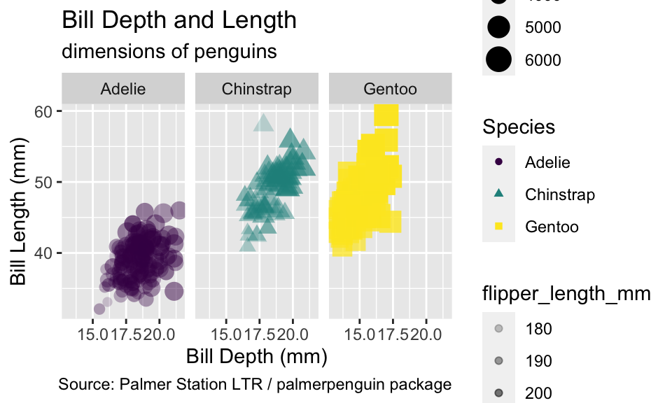

```r
library(tidyverse)
library(palmerpenguins)
ggplot(data = penguins, ###can use color, shape, size, and alpha (transparency)
  mapping = aes(x = bill_depth_mm, ### x data ###
                y = bill_length_mm, ### y data ###
                size = body_mass_g, ### size based off body mass
                alpha = flipper_length_mm, ###when I want the transparency to be based off the values
                color = species,  ### I can also make color and shape different things##
                shape = species))+  ### this adds color and shape to same category###
  geom_point() +  ### if I want all points to look the same I can put color, size and shape here
  labs(title = "Bill Depth and Length",
       subtitle = "dimensions of penguins",
       x = "Bill Depth (mm)",
       y = "Bill Length (mm)",
       color = "Species",
       shape = "Species",
       caption = "Source: Palmer Station LTR / palmerpenguin package")+
       scale_color_viridis_d() +
#facet_grid (species~sex) ### means sex as a function of species+
facet_wrap(~species)  ### not a grid and wrapping by species,
```

```r
### only columns use right of ~, only rows use left of ~, ncol to specify number of columns
#guides(color = FALSE) #deletes legend
```

## dplyr

from week_4a  
part of tidyverse  
### filter **filter()** extract rows  
filter(data_to_transform, stuff the verb does)

**==** - is exactly equal to  
**<=** less than or equal to  
**>=**  
**!=** not equal to  
**x %in% y** in (group membership)  
**is.na(x)** is missing  
**!is.na(x)** is not missing  
**&** and  
**|** or  
**!** not  
e.g  
**filter**(.data = penguins, sex == “female”) **filter**(.data = penguins,  
island %in% c(“Dream”, “Briscoe”)) # data in dream and briscoe **filter**(data= penguins,  
body_mass_g > 5000,  
body_mass_g < 3000) # body mass between 3k and 5k  
**filter(sex==“female”)** - Pick observations by their values  
& is “and”, | is “or”, and ! is “not”.

### select

**select()** extract columns  
**select(species, island, sex)** - Pick variables by their names

### arrange and relocate

**arrange()** arrange/sort rows  
put in alphabetical order

```r
EnviroData_wide<- EnviroData %>%
  pivot_wider(names_from = parameter.measured,
              values_from = values) %>%
  arrange(site.letter)
view(EnviroData_wide)
```

relocate example  
puts character data on left and numeric data on right

```r
# left join add the right to the left and excludes anything not in left
FullData_left<-left_join(TPCData,EnviroData_wide) %>%
  relocate(where(is.numeric), .after = where(is.character)) %>%
  arrange(site.letter)
```

### mutate

**mutate(data, stuff it does)** make new columns  
mutate_at(.table, .variables, .functions, …, .cols = NULL) - affects variables with a character vector or vars()  
e.g.  
mutate_at(vars(-group_cols(), …), myoperation)  
mutate_at(vars(matches(“Sepal”)), log) mutate_if(.table, .predicate, .functions, …) - selects variables with predicate function  
mutate_all(.table, .functions, …)- affects every variable  
[link with decription of mutate](https://dplyr.tidyverse.org/reference/mutate_all.html)  
implicit is _all or _is and explicit is _at  
**ifelse**(test, value_if_true, value_if_false)  
mutate(.data = penguins, after_2008 = ifelse(year>2008, “After 2008”, “Before 2008”))  
**drop_na(sex)** to drop rows with NAs from column sex  
**mutate(log_mass = log(body_mass_g))** - Create new variables with functions of existing variables

### the pipe

**%>%** the pipe means “and then”

### group_by and summarize

**group_by() %>% summarize()** to make group summaries

**summarise(mean_flipper = mean(flipper_length_mm, na.rm=TRUE))** - Collapse many values down to a single summary  
to exclude NA’s is na.rm=TRUE  
**.groups** in summarize can override ___

**group_by()** by itself does nothing with summarize is great

## tidyr

from week_4b -part of tidyverse  
library(tidyverse)  
library(here)

### another way to remove NAs

filter(**complete.cases(.)**) filters out everything that isn’t a complete row

### seperate

**separate**( - this functions deletes the original column  
data = [data frame you are using],  
col = [column that you want to separate],  
into = [name of the new columns],  
sep = [what are you separating by?])

### unite

**unite**(col = “Site_Zone”, # the name of the NEW col #to unite the names  
c(Site,Zone), # the columns to unite  
sep = “.”, # lets put a . in the middle  
remove = FALSE) # keep the original  
unite unites two columns into one

### pivot wide to long

easier to summarize using group_by because you only need to group by variable name  
easier to facet_wrap is all plot identical you don’t have to make 10 individual plots

**pivot_longer**(cols = Temp_in:percent_sgd, # the cols you want to pivot. This says select the temp to percent SGD cols names_to = “Variables”, # the names of the new cols with all the column names values_to = “Values”) # names of the new column with all the values  
+ facet_wrap(~Variables, scale = “free”) to make the scales different and uniform

### pivot long to wide

**pivot_wider**(names_from = Variables, values_from = mean_vals)

**example**

```r
ChemData_clean<-ChemData %>%
  filter(complete.cases(.)) %>% #filters out everything that is not a complete row
  separate(col = Tide_time, # choose the tide time col
           into = c("Tide","Time"), # separate it into two columns Tide and time
           sep = "_", # separate by _
           remove = FALSE) %>%
  pivot_longer(cols = Temp_in:percent_sgd, # the cols you want to pivot. This says select the temp to percent SGD cols
               names_to = "Variables", # the names of the new cols with all the column names
               values_to = "Values") %>% # names of the new column with all the values
  group_by(Variables, Site, Time) %>%
  summarise(mean_vals = mean(Values, na.rm = TRUE)) %>%
  pivot_wider(names_from = Variables,
              values_from = mean_vals) %>% # notice it is now mean_vals as the col name
  write_csv(here("Week_4","output","summary.csv"))  # export as a csv to the right folder

# summarise() has grouped output by 'Variables', 'Site'. You can override using the .groups argument.
```

## joins

from week_5a  
joins - join data from 2 files  
tibble - creates a table in r

create tibble  
tibble1<-tibble(Site.ID = c(“A”, “B”, “C”, “D”),  
Temperature = c(14.1, 16.7, 15.3, 12.8))  
tibble1

tibble2<-tibble(Site.ID = c(“A”, “B”, “D”, “E”),  
ph = c(7.3, 7.8, 8.1, 7.9))  
tibble2

**left_join**(tibble1, tibble2) joins to left and retains left data  
**right_join**(tibble1, tibble2) joins to right and retains only right data  
**inner_join**(tibble1, tibble2) # only retains the ones in both  
**full_join**(tibble1, tibble2) # reatains everything and has NA’s for missing  
**semi_join**(tibble1, tibble2) # only retain complete in both but also only left side  
**anti_join**(tibble1, tibble2) # keeps whatis in x thats completely missing in y (left side)

examples

```r
EnviroData_wide<- EnviroData %>%
  pivot_wider(names_from = parameter.measured,
              values_from = values) %>%
  arrange(site.letter)
view(EnviroData_wide)


# left join add the right to the left and excludes anything not in left
FullData_left<-left_join(TPCData,EnviroData_wide) %>%
  relocate(where(is.numeric), .after = where(is.character)) %>%
  arrange(site.letter)
### where is the data
head(FullData_left)


FullData_leftlong<-FullData_left %>%
  pivot_longer(cols = E:Topt,
               names_to = "variables",
               values_to = "values") %>%
  group_by(site.letter) %>%
  summarise(meandata = mean(values, na.rm = TRUE),
            vardata = var(values, na.rm = TRUE))
view(FullData_leftlong)
```

## lubridate

library(tidyverse)  
library(lubridate)  
library(here)  
**now**()  
now(tzone = “EST”)  
**today()**  
am(now())  
**leap_year(now())**  
*lubridate symbols*  
y - year  
m - month  
d - day  
h - hour  
m - minute  
s - second  
**date has to be a character**  
use **_csv** and not .cvs

**ymd**(“2021-02-24”) # or can type in the column  
mdy(“March 25, 1984”) # slash or write out  
dmy()  
**ymd_hms**(“2021-02-24 10:22:20 PM”)  
mdy_hms(“02/24/2021 22:22:20”)  
mdy_hm(“February 24 2021 10:22 PM”)  
**use c for vector**  
**make a character string**  
datetimes<-c(“02/24/2021 22:22:20”,  
“02/25/2021 11:21:10”,  
“02/26/2021 8:01:52”)  
**convert to datetimes**  
datetimes <- mdy_hms(datetimes)  
**month**(datetimes)  
month(datetimes, label = TRUE)  
**month(datetimes, label = TRUE, abbr = FALSE)** #Spell it out  
**day**(datetimes) # extract day  
**wday**(datetimes, label = TRUE) # extract day of week

### convert to datetimes

datetimes <- mdy_hms(datetimes)  
month(datetimes, label = TRUE, abbr = FALSE) #Spell it out  
day(datetimes) # extract day  
wday(datetimes, label = TRUE) # extract day of week  
hour(datetimes)  
minute(datetimes)  
second(datetimes)  
**datetimes + hours(4)** # this adds 4 hours  
s on end means to add information  
hour() extracts the hour component from a time and hours() is used to add  
hours to a datetime  
datetimes + days(2) # this adds 2 days  
**day()** extracts the hour component from a time and **days()** is used to add hours to a datetime  
**round_date**(datetimes, “minute”) # round to nearest minute  
round_date(datetimes, “5 mins”) # round to nearest 5 minute

example

```r
# this function joins the two data together where there are no NA's and only exact matches
# it also rounds the time to 1 minute and takes the mean of the date, temp, depth, and salinity
dep_con_data <- inner_join(depdata,condata) %>% # joins the two and omits the ones that dont match
  select(!date) %>% # this removes the original date column
  mutate(timebyminute = round_date(dateandtime, "1 minute")) %>% # this rounds by the minute
  group_by(timebyminute) %>% # grouping variable is time
  summarise_at(vars(c("dateandtime","TempInSitu","Depth","SalinityInSitu_1pCal")), list(mean = mean))
view(dep_con_data)
```

## rmarkdown

### main

from week_6  
YAML - yet another markdown language  
*yaml* includes metadata, style, and type, and output  
minimal need is title and output  
output: html_doc: toc: TRUE toc_float:TRUE  
theme: darkly  
install tinytex for better PDF documents  
Headers #-####### 1-6  
**bold** two astricks  
*italics* one astick  
new line is two spaces at end  
list is with “-” to create asterisks for 1. for number list  
1.  
1.  
1.  
images = ! [image name]  
(image link)  
link =  
[link name]  
(link)  
cmd+option+I to insert chunk  
format changes go inside the curly brackets spaces matter problems in yaml are usually with spacing google rmd formats to see lots of different formats

### chunk options

**include**=false - dont want to show code or results  
**echo** = false - shows results but not code  
**message** = false - prevents msgs generated by code  
**warning** = false prevents warnings from code  
**fig.cap** = “jflj;dj” - adds caption  
**eval** = false prevents code from beinf run  
global options call **knitr::opts_chunks$set** in code chunk within r setup box

#### figure options

**goes in the 4 curley brackets**  
change size  
change resolution  
change “device” (i.e. is it png, pdf, etc.)  
save to specific folder  
**out** for output and **fig** for figure

**out.width**=“70%” (makes it 70% of the width) –>  
**fig.width**=3 (makes the width 3 inches) –>  
**fig.height**t=4 (makes the width 4 inches) –>  
**fig.asp**=1.2 (changes the aspect ratio to 1.2) –>  
**fig.align**=“center” –>  
**fig.path** in the the top so apply to whole doc but cant use here r label,  
**fig path** cant use here function :( - where to put your figures when saved  
have to change label names for each one or it will keep saving over  
echo hides code **{r label, option1=value}** to name your code chunk

### kable tables

library(kableExtra)

**+kbl()** to make it a kable table  
%>% kable_classic()  
%>% row_spec(2, bold - T, color = “white”, background = “red”)  
%>% kable_styling(full_width = FALSE) - to not make full width of page

## Maps

from week_7  
link to hack to use link and see like html ggmaps uses google maps

**sf** (This is for the serious GIS people. If you want to do actual spatial analyses this is the package to use) **ggmap** (Uses the google maps API to make maps. Really easy to use, but requires a credit card for the API…) **tmap** (static and interactive maps) **leaflet** (interactive html maps)

map_data(“location”) is the function used to pull out whatever base layer that you want.

long is longitude. Things to the west of the prime meridian are negative.

lat is latitude.

order. This just shows in which order ggplot should “connect the dots”

region and subregion tell what region or subregion a set of points surrounds.

**group = group** This is very important! ggplot2’s functions can take a group argument which controls (amongst other things) whether adjacent points should be connected by lines. If they are in the same group, then they get connected, but if they are in different groups then they don’t. Essentially, having to points in different groups means that ggplot “lifts the pen” when going between them.

```r
library(tidyverse)
library(here)
library(maps)
library(mapdata)
library(mapproj)
```

### get data for the entire world

world<-map_data(“world”) head(world)

for usa map outline, lat and longs for outline

### get data for the USA

usa<-map_data(“usa”) head(usa) country italy

### get data for italy

italy<-map_data(“italy”) head(italy)

### get data for states

states<-map_data(“state”) head(states) tail(states)

group column tells you whne the pen is lifted when you are drawing

### **remember to put group = group**

### Mercator map

```r
ggplot()+
  geom_polygon(data = world, aes(x = long, y = lat, group = group,
                                 fill = region),
               color = "yellow") +
  guides(fill = FALSE) +
  theme_minimal() +
  theme(panel.background = element_rect(fill = "lightblue")) +
    coord_map(projection = "mercator", # mercator typical projection
            xlim = c(-180,180)) # add the limits to widen the map
```

```r
ggplot()+
  geom_polygon(data = world, aes(x = long, y = lat))
```

### Sinasoidal map

```r
ggplot()+
  geom_polygon(data = world,
               aes(x = long,
                   y = lat,
                   group = group,
                   fill = region),
               color = "black")+
  theme_minimal()+
  guides(fill = FALSE)+
  theme(panel.background = element_rect(fill = "lightblue"))+
  coord_map(projection = "sinusoidal",
            xlim = c(-180,180))
```

### Map of California

```r
states %>%
  filter(region == "california") %>%
  ggplot()+
  geom_polygon(aes(x = long,
               y = lat,
               group = group,
               fill = region))+
  coord_map()+
  theme_void() # deletes the background
calimap
head(counties)[1:3,]
```

maps including county data

### get county data

counties <-map_data(“county”)

```r
CApop_county <- popdata %>%
  select("subregion" = County, Population) %>%
  inner_join(counties) %>%
  filter(region == "california")

  ggplot()+
  geom_polygon(data = CApop_county,
               aes(x = long,
                   y = lat,
                   fill = Population,
                   group = group))+
  coord_map()+
    scale_fill_gradient(trans = "log10")+ # log 10 transforming the fill gradient
  theme_void()
```

### ggmap

Oahu <- get_map(“Oahu)  
ggmap(Oahu) WP<-data.frame(lon = -157.7621, lat = 21.27427) # coordinates for Wailupe **Get base layer**  
Map1<-get_map(WP) **plot it**  
ggmap(Map1) **zoom in** Map1<-get_map(WP,zoom = 17) ggmap(Map1)  
**change map type**  
Map1<-get_map(WP,zoom = 17, maptype =”satellite“) ggmap(Map1)  
**change maptype to watercolor**  
Map1<-get_map(WP,zoom = 17, maptype =”watercolor“) ggmap(Map1)  
**add base layer to any plot**  
Map1<-get_map(WP,zoom = 17, maptype =”satellite") ggmap(Map1)+ geom_point(data = ChemData, aes(x = Long, y = Lat, color = Salinity), size = 4) + scale_color_viridis_c()  
**add a scalebar**

[figure not shown]

```r
library(ggmap)
library(tidyverse)
library(here)
library(ggsn)
ChemData<-read_csv(here("Week_7","data7","chemicaldata_maunalua.csv"))

WP<-data.frame(lon = -157.7621, lat = 21.27427)
#Map1<-get_map(WP)
Map1<-get_map(WP,zoom = 17, maptype = "satellite")
ggmap(Map1)+
  geom_point(data = ChemData,
             aes(x = Long, y = Lat, color = Salinity),
             size = 4) +
  scale_color_viridis_c()+
  scalebar( x.min = -157.766, x.max = -157.758,
           y.min = 21.2715, y.max = 21.2785,
            dist = 250, dist_unit = "m", model = "WGS84",
            transform = TRUE, st.color = "white",
            box.fill = c("yellow", "white"))
```

### geocode  
Use geocode() to get exact locations that you can then use in the maps.

geocode(“the white house”)  
geocode(“California State University, Northridge”)

## Advanced plotting

### patchwork

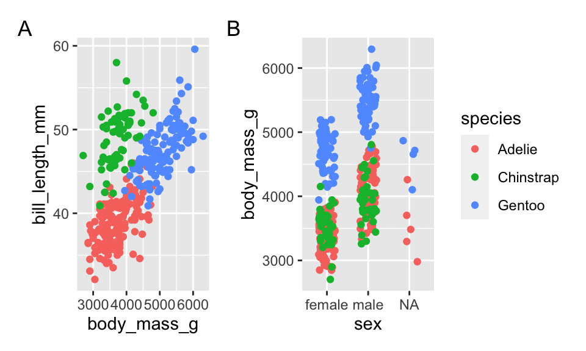

```r
library(patchwork)
library(ggplot2)
library(palmerpenguins)
# plot 1
p1 <- penguins %>%
    ggplot(aes(x = body_mass_g,
             y = bill_length_mm,
             color = species))+
  geom_point()

# plot 2
p2<-penguins %>%
  ggplot(aes(x = sex,
             y = body_mass_g,
             color = species))+
  geom_jitter(width = 0.2)

# adding plots 1 and 2
p1 + p2 +
  plot_layout(guides = 'collect')+
  plot_annotation(tag_levels = 'A')
```

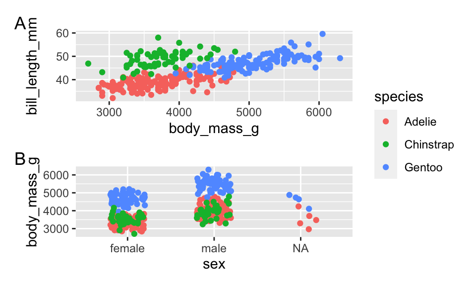

```r
p1/p2 +
  plot_layout(guides = 'collect')+
  plot_annotation(tag_levels = 'A')
```

### ggrepel

makes the data points repel  
label gives box  
text gives no box

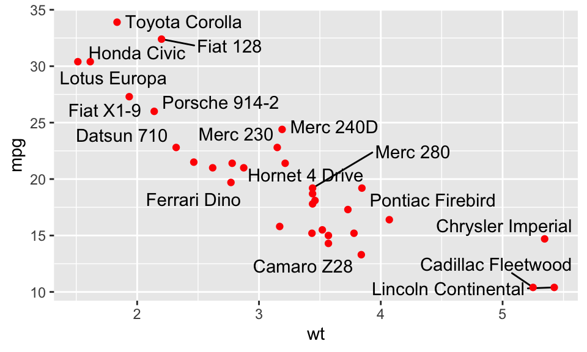

```r
library(ggrepel)
library(ggplot2)
# repels text
ggplot(mtcars, aes(x = wt,
                   y = mpg,
                   label = rownames(mtcars))) +
  geom_text_repel() + # repel them
  geom_point(color = 'red')
```

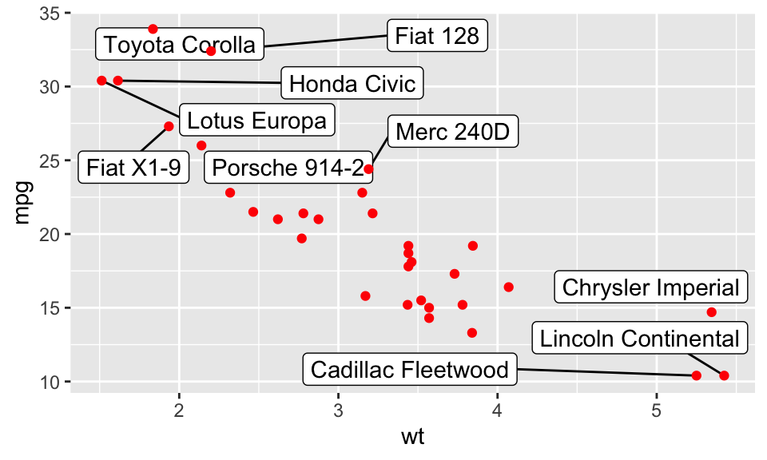

```r
# repels labels with box around
ggplot(mtcars, aes(x = wt,
                   y = mpg,
                   label = rownames(mtcars))) +
  geom_label_repel() + # repel them
  geom_point(color = 'red')
```

### gganimate

state_length is pause  
transition_length is  
curly bracket means take me out of quotes

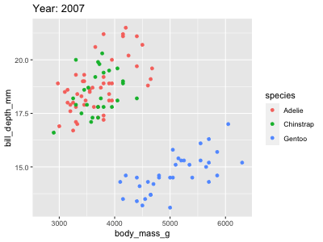

```r
library(gganimate)
library(palmerpenguins)
library(ggplot2)

anim <- penguins %>%
ggplot(aes(x = body_mass_g,
            y = bill_depth_mm,
            color = species)) +
  geom_point() +
  transition_states(
    year, # what we are animating by
    transition_length = 2,
    state_length = 1
  ) +
  ease_aes("sine-in-out") + # or 'bounce-in-out'
  ggtitle('Year: {closest_state}') # no plus!!!
animate(anim, height = 300, width = 400, nframes = 20)
```

to save an annimation add:

```r
 anim_save(here("week_8","output8","mypengiungif.gif"))
           # animate(penguins, renderer = gifski_renderer()))
```

### magick

to add images to your graphs  
- read_in image  
- save plot as image  
- make composite image

read in image

```r
library(palmerpenguins)
library(magick)
library(here)
library(ggplot2)
penguin<-image_read("https://pngimg.com/uploads/penguin/pinguin_PNG9.png")
penguinsmaller <- image_scale(penguin, "200")
penguinsmaller
```

Save plot as picture

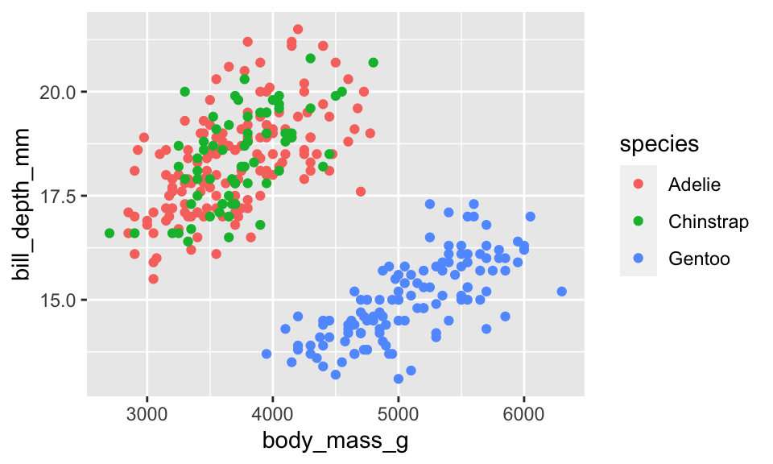

```r
penguins %>%
ggplot(aes(x = body_mass_g,
            y = bill_depth_mm,
            color = species)) +
  geom_point()
```

```r
  ggsave(here("week_8", "output8", "penguinplot.png"))
```

make a composite plot

[figure not shown]

```r
penplot<-image_read(here("week_8","output8","penguinplot.png"))
out <- image_composite(penplot, penguin, offset = "+70+30")
outsmaller <- image_scale(out, "500") # to make smaller for printing
outsmaller
```

can add a gif also

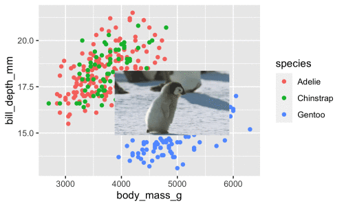

```r
# Read in a penguin gif
pengif<-image_read("https://media3.giphy.com/media/H4uE6w9G1uK4M/giphy.gif")
outgif <- image_composite(penplot, pengif, gravity = "center")
animation <- image_animate(outgif, fps = 10, optimize = TRUE)
# animation
#only for printing purpose
smalleranimation <- image_scale(animation, "500")
smalleranimation
```

## Creating functions

library(tidyverse)  
1. set up skeleton  
2. name function - easy  
3. enter arguments  
4. enter return  
5. add your defaults  
great for making a function that includes my style  
library(PNWColors)  
**tip** can put all in my functions in one script and write code to run that script  
** curly curly {{}}** tells r that this color is associated with a dat frame and not floating vector

```r
library(tidyverse)
F_to_C <- function(temp_F){
  temp_C <- (temp_F-32) * 5 / 9
  return(temp_C)
  }
```

test it

```r
F_to_C(32)
```

```
## [1] 0
```

add defaults

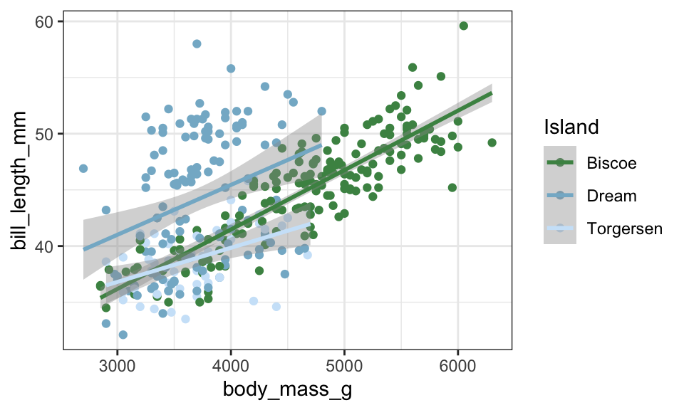

```r
library(palmerpenguins)
library(PNWColors)
library(tidyverse)
myplot<-function(data = penguins, x, y){ # made a default data
pal<-pnw_palette("Lake",3, type = "discrete") # my color palette
ggplot(data, aes(x = {{x}}, y = {{y}} , color = island))+
  geom_point()+
  geom_smooth(method = "lm")+ # add a linear model
  scale_color_manual("Island", values=pal)+   # use pretty colors and change the legend title
  theme_bw()
}
myplot(data = penguins, x = body_mass_g, y = bill_length_mm)
```

add an if-else statement

```r
a <- 4
b <- 5

#Suppose that if a > b then f should be = to 20, else f should be equal to 10. # Using if/else we:

if (a > b) { # my question
  f <- 20 # if it is true give me answer 1
    } else { # else give me answer 2
  f <- 10
}
f
```

```
## [1] 10
```

plotting

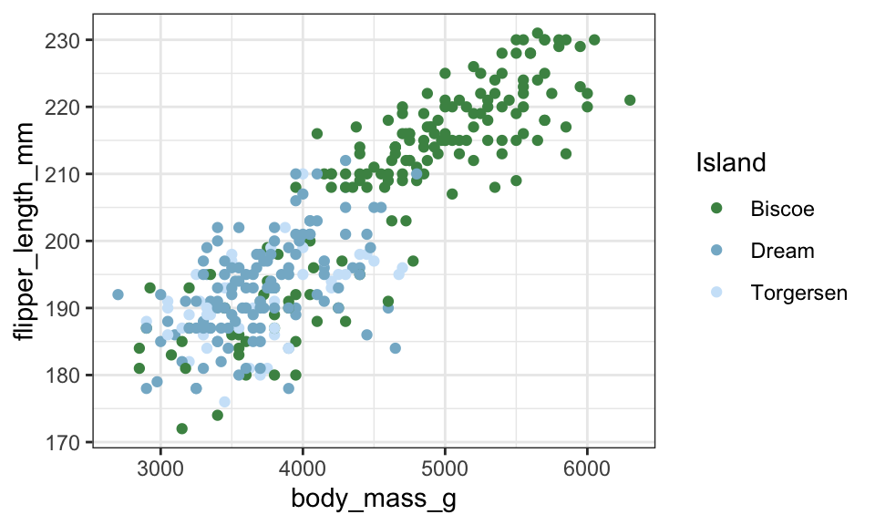

```r
myplot<-function(data = penguins, x, y, lines=TRUE ){ # add new argument for lines
pal<-pnw_palette("Lake",3, type = "discrete") # my color palette
if(lines==TRUE){
ggplot(data, aes(x = {{x}}, y = {{y}} , color = island))+
  geom_point()+
  geom_smooth(method = "lm")+ # add a linear model
  scale_color_manual("Island", values=pal)+   # use pretty colors and change the legend title
  theme_bw()
}
else{
ggplot(data, aes(x = {{x}}, y = {{y}} , color = island))+
  geom_point()+
  scale_color_manual("Island", values=pal)+   # use pretty colors and change the legend title
  theme_bw()
}
}

# test to see if remove lines
myplot(x = body_mass_g, y = flipper_length_mm, lines = FALSE)
```

## Awesome r packages

### give yourself praise

library(praise)  
praise()

### dad jokes

library(dadjoke)  
dadjoke()

### animals that talk

animals that talk to you  
library(cowsay)  
I want a shark to say hello  
say(“hello”, by = “shark”)  
say(by =“random”)

### catterplot

catterplot uses cats in your graphs

### make computer make beeping

library(beepr) beep(5)

### make memes

devtools::install_github(“sctyner/memer”) library(memer) meme_list() meme_get(“FryNotSure”) meme_get(“NoneOfMyBusiness”) %>% meme_text_top(“I don’t always like coding”, size = 28) %>% meme_text_bottom(“But when I do’s always today’s totally awesome R package”, size = 18)

### get fortunes

library(fortunes)  
fortune()

### to put sitting Bernie sanders on graph

library(ggbernie) +  
geom_bernie(aes(x = Salinity, y = NN), bernie = “sitting”)

### ggdogs

remotes::install_github(“R-CoderDotCom/ggdogs@main”)  
library(ggdogs)  
ggplot(mtcars) +  
geom_dog(aes(mpg, wt), dog = “pug”, size = 5)

### emojifont

to use emjis on graphs  
install.packages(“emojifont”)

library(emojifont) search_emoji(‘smile’)

ggplot() + geom_emoji(‘smile_cat’, x=1:5, y=1:5, size=10) [emojifont link info](https://cran.r-project.org/web/packages/emojifont/vignettes/emojifont.html)